# Visualize results of MB subgroup prediction

Steven Foltz

# Setup

```r
# Source code and libraries
source(here::here("utils/color_schemes.R"))
source(here::here("utils/convert_gene_names.R"))
source(here::here("utils/modeling.R"))
library(patchwork)

seed <- 44

# Define directories and input/output file paths
processed_data_dir <- here::here("processed_data")
models_dir <- here::here("models")
plots_dir <- here::here("plots")
plots_data_dir <- file.path(plots_dir, "data")

bulk_genex_filepath <- file.path(processed_data_dir, "bulk_genex.tsv")
bulk_metadata_filepath <- file.path(processed_data_dir, "bulk_metadata.tsv")

baseline_filepath <- file.path(models_dir, "baseline.rds")

baseline_plot_df_filepath <- file.path(plots_data_dir, "baseline_plots_df.tsv")
baseline_kappa_plot_filepath <- file.path(plots_dir, "baseline_kappa.pdf")
baseline_accuracy_plot_filepath <- file.path(plots_dir, "baseline_accuracy.pdf")
baseline_binary_TSP_plot_filepath <- file.path(plots_dir, "baseline_binary_TSP.pdf")
baseline_figure_filepath <- file.path(plots_dir, "baseline_figure.pdf")

# check that baseline model exists and read in the file
if (file.exists(baseline_filepath)) {

  baseline_list <- readr::read_rds(baseline_filepath)

  model_types <- c("ktsp_weighted", "ktsp_unweighted",
                   "rf_weighted", "rf_unweighted",
                   "lasso", "mm2s", "medullopackage")

} else {

  stop(glue::glue("Baseline model file ", baseline_filepath, " does not exist."))

}

# set subgroups analyzed in this notebook (canonical MB subgroups)
mb_subgroups <- c("G3", "G4", "SHH", "WNT")

# Read in essential data
bulk_genex_df <- readr::read_tsv(bulk_genex_filepath,
                                 show_col_types = FALSE) |>
  tibble::column_to_rownames(var = "gene")

bulk_metadata_df <- readr::read_tsv(bulk_metadata_filepath,
                                    show_col_types = FALSE) |>
  dplyr::filter(sample_accession %in% names(bulk_genex_df),
                subgroup %in% mb_subgroups)

bulk_genex_df <- bulk_genex_df |>
  dplyr::select(dplyr::all_of(bulk_metadata_df$sample_accession))

check_input_files(genex_df = bulk_genex_df,
                  metadata_df = bulk_metadata_df)
```

# Visualize Kappa and accuracy results

### Gather data

The variable `baseline_list` is a list of lists. The first level of lists correspond to different repeats using different training/testing sets. Within each repeat, there are list elements corresponding to particular model results (e.g., `ktsp_weighted` or `lasso`) as well as metadata about the repeat (e.g., the seed used for to determine training/testing sets). To create a data frame for plotting, we need to gather modeling metrics (Kappa and Balanced Accuracy) from each model across all the repeats.

```r
plot_df <- baseline_list |>
  purrr::map(return_model_metrics,
             model_types = model_types,
             metadata_df = bulk_metadata_df,
             labels = mb_subgroups,
             platforms = c("Array", "RNA-seq")) |>
  purrr::list_rbind(names_to = "repeat_index") |>
  dplyr::mutate(model_type = dplyr::case_match(model_type,
                                               "ktsp_unweighted" ~ "kTSP (unw)",
                                               "ktsp_weighted" ~ "kTSP (w)",
                                               "rf_unweighted" ~ "RF (unw)",
                                               "rf_weighted" ~ "RF (w)",
                                               "mm2s" ~ "MM2S",
                                               "lasso" ~ "LASSO",
                                               "medullopackage" ~ "medulloPackage"))

readr::write_tsv(x = plot_df,
                 file = baseline_plot_df_filepath)
```

### Kappa tables

Kappa measures how often our predicted subgroups agree with the true subgroups, accounting for the chance of random agreement (necessary when subgroups are imbalanced). Kappa is an overall measure that applies to an entire set of predictions across subgroups. Values of Kappa closer to 1 indicate higher agreement, and values closer to 0 indicate random assignment.

$$\kappa = \frac{p_o - p_e}{1 - p_e}$$

where $p_o$ is the observed proportion of agreement and $p_e$ is the expected proportion of chance agreement.

The following table summarizes Kappa values stratified by platform (Array or RNA-seq) and model type by showing the median Kappa value.

```r
plot_df |>
  dplyr::filter(metric == "Kappa") |>
  dplyr::group_by(platform, model_type) |>
  dplyr::summarize(median_kappa = median(value),
                   .groups = "drop") |>
  tidyr::pivot_wider(names_from = platform,
                     values_from = median_kappa) |>
  knitr::kable(caption = "Median Kappa values (by platform)")
```

Median Kappa values (by platform)

| model_type | Array | RNA-seq |
| --- | --- | --- |
| LASSO | 0.9082242 | 0.9182389 |
| MM2S | 0.8896437 | 0.9128884 |
| RF (unw) | 0.9391809 | 0.9368836 |
| RF (w) | 0.9587773 | 0.9605689 |
| kTSP (unw) | 0.9685621 | 0.9607861 |
| kTSP (w) | 0.9607600 | 0.9421613 |
| medulloPackage | 0.9638834 | 0.8561333 |

- **Main point: the unweighted kTSP model performed best across both Array and RNA-seq data types**
- Median model performance is higher for Array test data compared to RNA-seq test data for kTSP models (unweighted and weighted) and medulloPackage
- Median model performance is similar Array and RNA-seq test data for LASSO, MM2S, and RF models
- For Array data, the model rankings from lowest median Kappa to highest: MM2S, LASSO, RF (unw), RF (w), kTSP (w), medulloPackage, kTSP (unw)
- For RNA-seq data, the model rankings from lowest median Kappa to highest: medullopackage, MM2S, LASSO, RF (unw), kTSP (w), RF (w), kTSP (unw)
- medulloPackage showed high performance in Array but low performance in RNA-seq, making its overall ranking unclear
  - medulloPackage performance on RNA-seq is further complicated by the wide range of Kappa values returned from different testing sets
  - For some testing sets, performance of medulloPackage was comparable to kTSP (unw)
  - see more about Medullopackage on RNA-seq below

### Plot Kappa

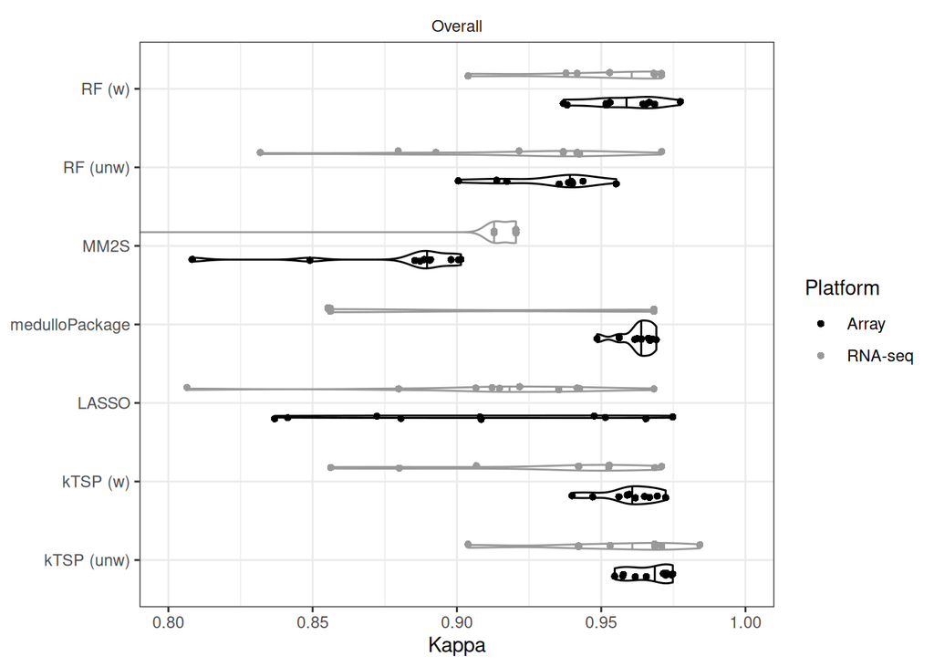

```r
set.seed(seed)

baseline_kappa_plot <- plot_df |>
  dplyr::filter(metric == "Kappa") |>
  ggplot2::ggplot(ggplot2::aes(x = value,
                               y = model_type,
                               color = platform)) +
  ggplot2::geom_violin(draw_quantiles = 0.5,
                       position = ggplot2::position_dodge(0.7),
                       show.legend = FALSE) +
  ggplot2::geom_point(shape = 16,
                      position = ggplot2::position_jitterdodge(jitter.width = 0.1,
                                                               jitter.height = 0)) +
  ggplot2::coord_cartesian(xlim = c(0.8,1)) +
  ggplot2::facet_wrap(~ subgroup,
                      ncol = 1) +
  ggplot2::labs(x = "Kappa",
                y = NULL,
                color = "Platform") +
  ggplot2::scale_color_manual(values = platform_colors) +
  ggplot2::scale_fill_manual(values = c("#FFFFFF", "#FFFFFF")) +
  ggplot2::theme_bw() +
  ggplot2::theme(strip.background = ggplot2::element_blank())
ggplot2::ggsave(filename = baseline_kappa_plot_filepath,
                plot = baseline_kappa_plot,
                height = 7,
                width = 7)

baseline_kappa_plot
```

To aid in visualization, the following data points were excluded from the previous plot. Later we explore these excluded data points in more detail.

```r
plot_df |>
  dplyr::filter(metric == "Kappa",
                value < 0.8)
```

| repeat_index | model_type | official_model | platform | study | total_samples | subgroup | subgroup_samples | metric | value |
| --- | --- | --- | --- | --- | --- | --- | --- | --- | --- |
| 4 | MM2S | FALSE | RNA-seq | GSE164677 | 59 | Overall | 59 | Kappa | 0.5185771 |
| 6 | MM2S | FALSE | RNA-seq | GSE164677 | 59 | Overall | 59 | Kappa | 0.5185771 |

### Excluded data points

What’s up with the MM2S model on RNA-seq data from repeats 4 and 6? As shown above, repeats 4 and 6 used the same test set and had the exact same Kappa value for the MM2S model. Note, this analysis will be specific to the particular data sets and parameters used in the original creation of this notebook.

```r
mm2s_rnaseq_repeat_4_df <- baseline_list[[4]]$test_metadata |>
  dplyr::filter(platform == "RNA-seq") |>
  dplyr::left_join(baseline_list[[4]]$mm2s$test_results$model_output,
                   by = c("sample_accession" = "SampleName"))
```

#### MM2S RNA-seq Repeat 4 (and 6)

MM2S showed poor performance on GSE164677 data.

```r
calculate_confusion_matrix(predicted_labels = mm2s_rnaseq_repeat_4_df$MM2S_Prediction,
                           true_labels = mm2s_rnaseq_repeat_4_df$subgroup,
                           labels = mb_subgroups)$table
```

```
##           Reference
## Prediction G3 G4 SHH WNT
##        G3   6  6   0   0
##        G4   0 12   0   0
##        SHH  5  0  13   0
##        WNT  3  1   6   6
```

#### medulloPackage on RNA-seq

medulloPackage performed best on OpenPBTA data (Kappa = 0.968) and worse on data from GSE164677 (n = 59, Kappa = 0.855) and St. Jude (n = 57, Kappa = 0.856)

```r
plot_df |>
  dplyr::filter(model_type == "medulloPackage",
                platform == "RNA-seq",
                metric == "Kappa") |>
  dplyr::select(study, total_samples, metric, value) |>
  dplyr::arrange(value)
```

| study | total_samples | metric | value |
| --- | --- | --- | --- |
| GSE164677 | 59 | Kappa | 0.8553331 |
| GSE164677 | 59 | Kappa | 0.8553331 |
| St. Jude | 57 | Kappa | 0.8561333 |
| St. Jude | 57 | Kappa | 0.8561333 |
| St. Jude | 57 | Kappa | 0.8561333 |
| St. Jude | 57 | Kappa | 0.8561333 |
| OpenPBTA | 96 | Kappa | 0.9682645 |
| OpenPBTA | 96 | Kappa | 0.9682645 |
| OpenPBTA | 96 | Kappa | 0.9682645 |
| OpenPBTA | 96 | Kappa | 0.9682645 |

### Accuracy tables

Balanced accuracy is the average sensitivity and specificity of a model and is measured per subgroup.

$$\text{Balanced Accuracy} =
\frac{Sensitivity + Specificity}{2}$$

where

$$\text{Sensitivity} = \frac{TP}{TP + FN}
\text{ and Specificity} = \frac{TN}{TN + FP}$$

for true and false positive and negative predictions.

#### Array test data

```r
plot_df |>
  dplyr::filter(metric == "Balanced Accuracy",
                platform == "Array") |>
  dplyr::group_by(model_type, subgroup) |>
  dplyr::summarize(median_accuracy = median(value),
                   .groups = "drop") |>
  dplyr::mutate(median_accuracy = round(median_accuracy, 3)) |>
  tidyr::pivot_wider(names_from = subgroup,
                     values_from = median_accuracy) |>
knitr::kable(caption = "Median Balanced Accuracy values")
```

Median Balanced Accuracy values

| model_type | G3 | G4 | SHH | WNT |
| --- | --- | --- | --- | --- |
| LASSO | 0.869 | 0.952 | 0.994 | 0.968 |
| MM2S | 0.873 | 0.946 | 0.975 | 0.953 |
| RF (unw) | 0.902 | 0.964 | 0.997 | 0.991 |
| RF (w) | 0.936 | 0.978 | 0.997 | 0.982 |
| kTSP (unw) | 0.959 | 0.980 | 0.997 | 0.986 |
| kTSP (w) | 0.947 | 0.979 | 0.996 | 0.985 |
| medulloPackage | 0.979 | 0.979 | 0.991 | 0.978 |

#### RNA-seq test data

```r
plot_df |>
  dplyr::filter(metric == "Balanced Accuracy",
                platform == "RNA-seq") |>
  dplyr::group_by(model_type, subgroup) |>
  dplyr::summarize(median_accuracy = median(value),
                   .groups = "drop") |>
  dplyr::mutate(median_accuracy = round(median_accuracy, 3)) |>
  tidyr::pivot_wider(names_from = subgroup,
                     values_from = median_accuracy) |>
  knitr::kable(caption = "Median Balanced Accuracy values")
```

Median Balanced Accuracy values

| model_type | G3 | G4 | SHH | WNT |
| --- | --- | --- | --- | --- |
| LASSO | 0.965 | 0.950 | 0.977 | 1.000 |
| MM2S | 0.890 | 0.912 | 0.958 | 0.988 |
| RF (unw) | 0.937 | 0.960 | 0.979 | 1.000 |
| RF (w) | 0.979 | 0.970 | 0.980 | 1.000 |
| kTSP (unw) | 0.990 | 0.974 | 0.980 | 1.000 |
| kTSP (w) | 0.989 | 0.965 | 0.980 | 1.000 |
| medulloPackage | 0.971 | 0.975 | 0.950 | 0.929 |

The following plot illustrates the differences observed between model types in G3 subgroup Balanced Accuracy.

### Plot accuracy (G3 only)

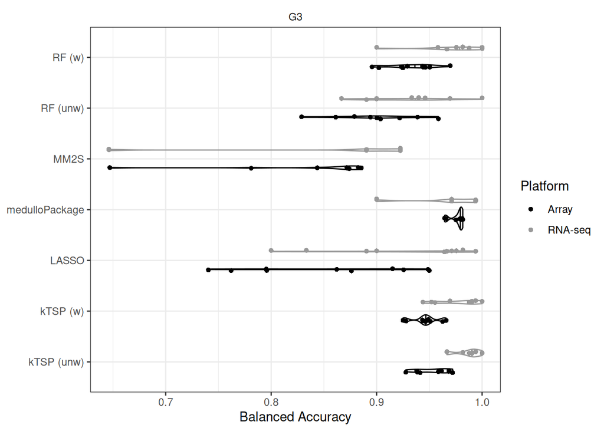

```r
set.seed(seed)

baseline_accuracy_plot <- plot_df |>
  dplyr::filter(metric == "Balanced Accuracy",
                subgroup %in% c("G3")) |>
  ggplot2::ggplot(ggplot2::aes(x = value,
                               y = model_type,
                               color = platform)) +
  ggplot2::geom_violin(draw_quantiles = 0.5,
                       show.legend = FALSE,
                       position = ggplot2::position_dodge(0.7)) +
  ggplot2::geom_point(shape = 16,
                      position = ggplot2::position_jitterdodge(jitter.width = 0.1,
                                                               jitter.height = 0)) +
  ggplot2::facet_wrap(~ subgroup,
                      ncol = 1) +
  #ggplot2::coord_cartesian(xlim = c(0.6,1)) +
  ggplot2::labs(x = "Balanced Accuracy",
                y = NULL,
                color = "Platform") +
  ggplot2::scale_fill_manual(values = c("#FFFFFF", "#FFFFFF")) +
  ggplot2::scale_color_manual(values = platform_colors) +
  ggplot2::theme_bw() +
  ggplot2::theme(strip.background = ggplot2::element_blank())

ggplot2::ggsave(filename = baseline_accuracy_plot_filepath,
                plot = baseline_kappa_plot,
                height = 7,
                width = 7)

baseline_accuracy_plot
```

### kTSP (unweighted) binary rules plot

```r
official_model <- baseline_list |>
  purrr::map_lgl("official_model") |>
  which()
official_train_test_seed <- baseline_list[[official_model]]$train_test_seed
official_ktsp_model <- baseline_list[[official_model]][["ktsp_unweighted"]]$classifier
official_ktsp_test_results <- baseline_list[[official_model]][["ktsp_unweighted"]]$test_results$model_output

test_samples <- baseline_list[[official_model]]$test_metadata$sample_accession

# confirm it's the same test samples in the same order
if (any(test_samples != row.names(official_ktsp_test_results))) {

  stop("Testing sets do not match!")

} else { # use train_test_samples_list and classifier to visualize binary rules

  genex_df_test <- bulk_genex_df |>
    dplyr::select(dplyr::all_of(test_samples))
  metadata_df_test <- bulk_metadata_df |>
    dplyr::filter(sample_accession %in% test_samples)

  test_data_object <- multiclassPairs::ReadData(Data = genex_df_test,
                                                Labels = metadata_df_test$subgroup,
                                                Platform = metadata_df_test$platform,
                                                verbose = FALSE)

  # The plot_binary_TSP() output cannot be saved to a variable directly, but
  # saving the plot as a function call makes it available to call again later
  # Source: https://stackoverflow.com/a/46961131
  binary_TSP_plot <- \() {multiclassPairs::plot_binary_TSP(Data = test_data_object,
                                                           classifier = official_ktsp_model,
                                                           prediction = official_ktsp_test_results,
                                                           classes = mb_subgroups,
                                                           show_rule_name = FALSE,
                                                           show_platform = FALSE,
                                                           ref_col = subgroup_colors,
                                                           pred_col = subgroup_colors,
                                                           legend = FALSE,
                                                           anno_height = 0.05,
                                                           score_height = 0.05,
                                                           margin = c(0, 5, 0, 0.5))}

  binary_TSP_plot_object <- patchwork::wrap_elements(full = ~ binary_TSP_plot())

  ggplot2::ggsave(filename = baseline_binary_TSP_plot_filepath,
                  plot = binary_TSP_plot_object,
                  width = 7,
                  height = 7)

}
```

### kTSP (unweighted) confusion matrix

```r
baseline_list[[official_model]][["ktsp_unweighted"]]$cm
```

```
## Confusion Matrix and Statistics
##
##           Reference
## Prediction  G3  G4 SHH WNT
##        G3  165   8   0   0
##        G4    9 391   0   1
##        SHH   0   0 323   1
##        WNT   0   0   1  94
##
## Overall Statistics
##
##                Accuracy : 0.9799
##                  95% CI : (0.9691, 0.9877)
##     No Information Rate : 0.4018
##     P-Value [Acc > NIR] : < 2.2e-16
##
##                   Kappa : 0.9709
##
##  Mcnemar's Test P-Value : NA
##
## Statistics by Class:
##
##                      Class: G3 Class: G4 Class: SHH Class: WNT
## Sensitivity             0.9483    0.9799     0.9969    0.97917
## Specificity             0.9902    0.9832     0.9985    0.99889
## Pos Pred Value          0.9538    0.9751     0.9969    0.98947
## Neg Pred Value          0.9890    0.9865     0.9985    0.99777
## Precision               0.9538    0.9751     0.9969    0.98947
## Recall                  0.9483    0.9799     0.9969    0.97917
## F1                      0.9510    0.9775     0.9969    0.98429
## Prevalence              0.1752    0.4018     0.3263    0.09668
## Detection Rate          0.1662    0.3938     0.3253    0.09466
## Detection Prevalence    0.1742    0.4038     0.3263    0.09567
## Balanced Accuracy       0.9693    0.9816     0.9977    0.98903
```

# Baseline figure

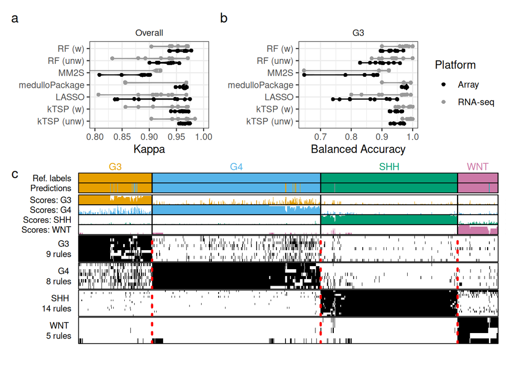

```r
panel_a_b <- baseline_kappa_plot + baseline_accuracy_plot +
  patchwork::plot_layout(guides = "collect")
panel_c <- patchwork::wrap_elements(full = ~ binary_TSP_plot())

figure_plot <- panel_a_b / panel_c +
  patchwork::plot_annotation(tag_levels = 'a') +
  patchwork::plot_layout(nrow = 2,
                         heights = c(1,2))

ggplot2::ggsave(filename = baseline_figure_filepath,
                plot = figure_plot,
                width = 7.5,
                height = 6)

figure_plot
```